# Practical Machine Learning - Prediction Assignment

Alexandra Tram

4/15/2019

# Background

Using devices such as Jawbone Up, Nike FuelBand, and Fitbit it is now possible to collect a large amount of data about personal activity relatively inexpensively. These type of devices are part of the quantified self movement - a group of enthusiasts who take measurements about themselves regularly to improve their health, to find patterns in their behavior, or because they are tech geeks. One thing that people regularly do is quantify how much of a particular activity they do, but they rarely quantify how well they do it. In this project, your goal will be to use data from accelerometers on the belt, forearm, arm, and dumbell of 6 participants. They were asked to perform barbell lifts correctly and incorrectly in 5 different ways. More information is available from the website here (see the section on the Weight Lifting Exercise Dataset).

# Loading and Processing the Raw Data

The data for this project come from this source

The training data for this project are available here:

https://d396qusza40orc.cloudfront.net/predmachlearn/pml-training.csv

The test data are available here:

https://d396qusza40orc.cloudfront.net/predmachlearn/pml-testing.csv

# Goal

The goal of your project is to predict the manner in which they did the exercise. This is the “classe” variable in the training set. Any of the other variables used to predict with.

1. create a report describing how you built your model,
2. how cross validation used,
3. what the expected out of sample error is, and
4. why the choices made
5. use a prediction model to predict 20 different test cases

# Read data

```r
rm( list=ls() )

library(data.table)
library(caret)
```

```r
setwd("/mapr/mapre04p/analytics0001/analytic_users/uocix/cc")
train<- read.csv("pml-training.csv")
test<- read.csv("pml-testing.csv")
dim(train)
```

```
## [1] 19622   159
```

```r
dim(test)
```

```
## [1]  20 159
```

# Remove columns with missing values

```r
train <- train[, colSums(is.na(train)) == 0]
test <- test[, colSums(is.na(test)) == 0]
classe <- train$classe
trainR <- grepl("^X|timestamp|window|user_name", names(train))
train <- train[, !trainR]
trainM <- train[, sapply(train, is.numeric)]
trainM$classe <- classe
testR <- grepl("^X|timestamp|window|user_name", names(test))
test<- test[, !testR]
testM <- test[, sapply(test, is.numeric)]
```

# Training data split

70% for train data and 30% for test data as this will be used for cross validation purpose

```r
set.seed(66666)
inTrain <- createDataPartition(trainM$classe, p=0.70, list=F)
train_data <- trainM[inTrain, ]
test_data <- trainM[-inTrain, ]
```

# Modelling using Random Forest and Cross Validation for tuning parameter

```r
setting <- trainControl(method="cv", 5)
RandomForest <- train(classe ~ ., data=train_data, method="rf", trControl=setting, ntree=100)
RandomForest
```

```
## Random Forest
##
## 13737 samples
##    52 predictor
##     5 classes: 'A', 'B', 'C', 'D', 'E'
##
## No pre-processing
## Resampling: Cross-Validated (5 fold)
## Summary of sample sizes: 10989, 10991, 10990, 10988, 10990
## Resampling results across tuning parameters:
##
##   mtry  Accuracy   Kappa
##    2    0.9902458  0.9876608
##   27    0.9905369  0.9880289
##   52    0.9857327  0.9819508
##
## Accuracy was used to select the optimal model using  the largest value.
## The final value used for the model was mtry = 27.
```

# Variable Importance - plot top 20 features

```r
gbmImp <- varImp(RandomForest, scale = FALSE)
gbmImp
```

```
## rf variable importance
##
##   only 20 most important variables shown (out of 52)
##
##                      Overall
## roll_belt             1423.6
## pitch_forearm          813.2
## yaw_belt               772.3
## pitch_belt             684.2
## magnet_dumbbell_z      630.6
## roll_forearm           623.3
## magnet_dumbbell_y      596.6
## accel_dumbbell_y       337.1
## accel_forearm_x        273.0
## magnet_dumbbell_x      256.7
## roll_dumbbell          252.4
## magnet_belt_z          236.8
## magnet_forearm_z       231.4
## accel_dumbbell_z       208.8
## accel_belt_z           203.0
## total_accel_dumbbell   191.5
## gyros_belt_z           182.7
## magnet_belt_y          179.4
## yaw_arm                162.3
## magnet_belt_x          157.8
```

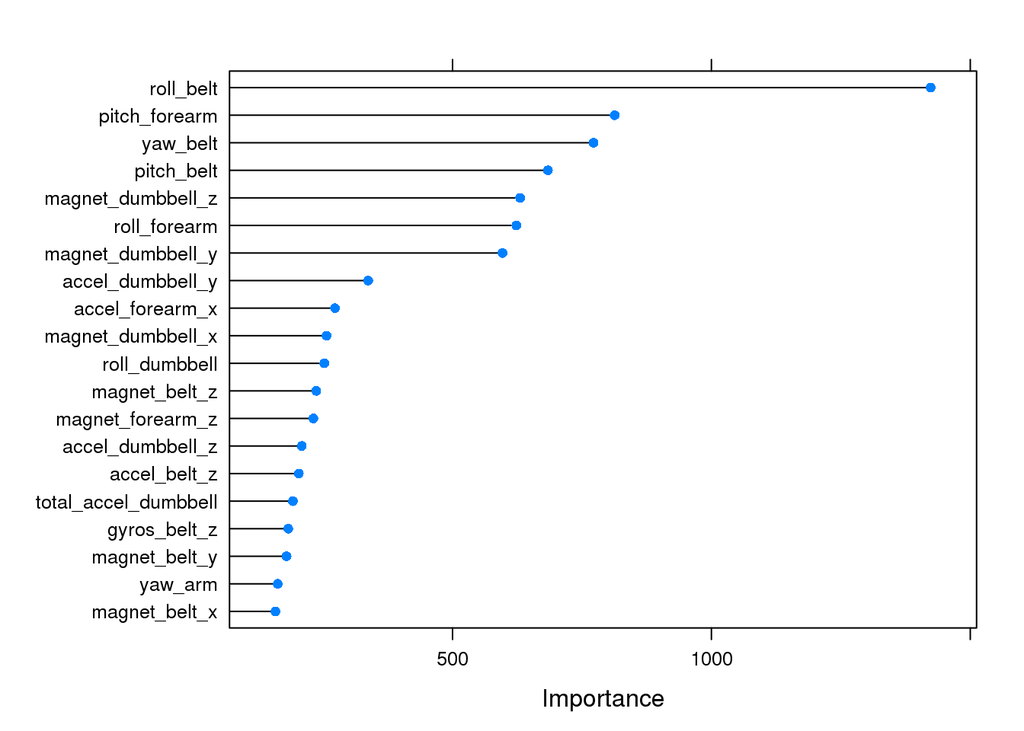

```r
plot(gbmImp, top = 20)
```

# Data Prediction / Accuracy / Error

```r
predict_RandomForest <- predict(RandomForest, test_data)
confusionMatrix(test_data$classe, predict_RandomForest)
```

```
## Confusion Matrix and Statistics
##
##           Reference
## Prediction    A    B    C    D    E
##          A 1672    2    0    0    0
##          B    9 1129    1    0    0
##          C    0    2 1021    3    0
##          D    0    0    6  957    1
##          E    0    0    2    8 1072
##
## Overall Statistics
##
##                Accuracy : 0.9942
##                  95% CI : (0.9919, 0.996)
##     No Information Rate : 0.2856
##     P-Value [Acc > NIR] : < 2.2e-16
##
##                   Kappa : 0.9927
##  Mcnemar's Test P-Value : NA
##
## Statistics by Class:
##
##                      Class: A Class: B Class: C Class: D Class: E
## Sensitivity            0.9946   0.9965   0.9913   0.9886   0.9991
## Specificity            0.9995   0.9979   0.9990   0.9986   0.9979
## Pos Pred Value         0.9988   0.9912   0.9951   0.9927   0.9908
## Neg Pred Value         0.9979   0.9992   0.9981   0.9978   0.9998
## Prevalence             0.2856   0.1925   0.1750   0.1645   0.1823
## Detection Rate         0.2841   0.1918   0.1735   0.1626   0.1822
## Detection Prevalence   0.2845   0.1935   0.1743   0.1638   0.1839
## Balanced Accuracy      0.9971   0.9972   0.9951   0.9936   0.9985
```

```r
accuracy <- postResample(predict_RandomForest, test_data$classe)
accuracy
```

```
##  Accuracy     Kappa
## 0.9942226 0.9926915
```

```r
error<-1 - as.numeric(confusionMatrix(test_data$classe, predict_RandomForest)$overall[1])
error
```

```
## [1] 0.0057774
```

# Decision Tree plot

The model we are using is random forest, which is not a single decision tree, but an ensemble of a large number of trees. Plotting the final model will plot the error rates on the training and test datasets as a number of trees are increased, something like the following.

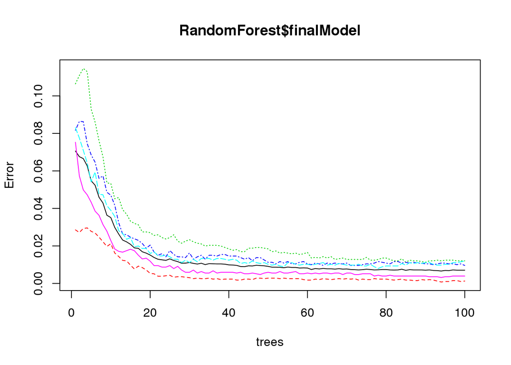

```r
plot(RandomForest$finalModel)
```

# Predicting Results on the Test Data

```r
predict_RandomForest_TEST <- predict(RandomForest, test)
predict_RandomForest_TEST
```

```
##  [1] B A B A A E D B A A B C B A E E A B B B
## Levels: A B C D E
```